# Determinants de l’accès au test de depistage VIH

Dimitry Yonta

2025-01-07

Après six décennies de lutte contre le virus de l’immunodéficience humaine, l’infection occupe toujours une place proéminente parmi les problèmes de santé publique. La transmission est particulièrement élevée en Afrique subsaharienne. Face à cette crise sanitaire, le programme commun des Nations Unies et d’autres organismes internationaux ont mis en œuvre plusieurs stratégies et ont fixé l’objectif 95-95-95, visant à ce que 95 % des personnes infectées connaissent leur statut, 95 % des personnes connaissant leur statut aient accès au traitement antirétroviral, et 95 % de celles sous traitement aient une charge virale supprimée avant 2030.

D’après les résultats de l’enquête démographique et de santé 2018, des progrès ont été réalisés dans la lutte contre cette pandémie au Cameroun. Cependant, force est de constater que le dépistage, porte d’entrée de l’objectif 95-95-95, reste limité. Ainsi, nous nous proposons d’explorer les déterminants de l’accès au dépistage du VIH au Cameroun en insitant sur le niveau de connaissance sur le VIH, attitudes discriminatoires et des pratiques sexuelles. Nous utiliserons les données de l’enquête démographique et de santé de l’année 2018.Cette exploration permettra de cibler les groupes présentant les risques les plus faibles de dépistage et d’accélérer l’atteinte de l’objectif 95-95-95. Nous utiliserons une approche cas-Temoin où les cas sont des personnes ayant été depistées au VIH au cours des 12 derniers mois précedant la collecte des données et les temoins ceux n’ayant pas été depisté au cours de la meme periode.Le modèle de régression logistique sera utilisé pour modeliser la relation entre les differents facteurs et le dépistage.

## 1 Importation des donnees, selection des variables et recodage.

```r
## Chargement des packages et definitions des parametres-----

if (!require(pacman)) install.packages("pacman")
pacman::p_load(foreign, haven,tidyverse,survey,gtsummary,rio,here,flextable,janitor, forcats, labelled)

theme_gtsummary_language( "fr", decimal.mark = ",", big.mark = " ")
```

```
## Setting theme "language: fr"
```

```r
## Importation de la base----

base_homme <- read_sas("C:/Users/DELL/OneDrive/Desktop/Mes Projets_R/epidemioR/DHS SAS/CMMR71SD/Bon.SAS7BDAT")

base_femme <- read_sas('C:/Users/DELL/OneDrive/Desktop/Mes Projets_R/epidemioR/DHS SAS/CMIR71SD/BONN.SAS7BDAT')


## Selection des variables----

base_EDS_homme <- base_homme %>%
  select(MCASEID,MV001, MV002, MV003,MV005,MV012,MV013 ,MV021,MV023,MV024, MV025, MV106,MV130, MV190,MV481,MV501,
         MV503, MV504, MV505,MV511,MV525,MV529,MV531,MV714,MV750,MV751, MV754CP,MV754DP,MV756,MV754JP,MV823,MV754WP,MV763A,MV774C,MV774B,MV774A,
         MV824,MV783,MV856,MV857A,MV527,MV825,MV832B,MV832C,MV852A,MV852B,MV852C,MV857C,MV857D,MV857B,MV858,MV777A,MV766A,MV766B,MV826A,MV833A,MV833B,MV833C,MV836,
         MV793,MV791A,MV793B,MV525,MV781,MV828)


base_EDS_femme <- base_femme %>%
  select(CASEID,V001, V002, V003,V005,V012,V013,V021,V023, V024,V763A, V025, V106, V130, V190,V481, V501, V503,
         V504, V505,V511,V525,V529,V531,V714,V750,V751, V754CP,V754DP,V756,V754JP,V823,V754WP,V774C,V774B,V774A,V824,V826A,
         V783,V856,V857A,V825,V527,V832B,V832C,V852A,V852B,V852C,V857C,V857D,V857B,V858,V777A,V766A,V766B,V833A,V833B,V833C,V836,V525,
         V781,V828, V791A)

base_EDS_femme <- base_EDS_femme %>%
  mutate( SEXE = ifelse(!is.na(CASEID), "Feminin","o")) #creaction de la variables sexe dans la base des femmes


base_EDS_homme <- base_EDS_homme %>%
  mutate( SEXE = ifelse(!is.na(MCASEID), "Masculin","o"))

## Renommons les variables----

base_EDS_femme <- base_EDS_femme %>%
  rename(MCASEID =CASEID,MV001=V001, MV002 =V002,
         MV003 = V003,MV005= V005,MV012 =V012,MV013 =V013,MV021 =V021,MV023 =V023 ,MV024 =V024,
         MV025 =V025, MV529 = V529, MV106 = V106,MV130 =V130, MV190 =V190,MV481 = V481,MV501 = V501,
         MV503 = V503, MV504= V504, MV505=V505,MV511 = V511,MV525=V525,MV527 = V527,MV714 = V714,MV750=V750,MV751 = V751 ,MV754CP=V754CP,MV754DP =V754DP,
         MV756 = V756,MV754JP = V754JP,MV823 = V823,MV754WP = V754WP,MV774C = V774C,MV763A =V763A,
         MV774B = V774B,MV774A = V774A,MV824 = V824,MV783 = V783,MV856 = V856,
         MV857A = V857A,MV825 = V825,MV826A = V826A,MV857C = V857C,MV857D = V857D,MV857B=V857B,MV858 = V858,
         MV777A =V777A,MV766A= V766A,MV766B = V766B,MV832C = V832C,MV832B = V832B,MV852A=V852A,MV852B = V852B,MV852C=V852C,MV833A = V833A,MV833B = V833B,MV833C = V833C,MV836 = V836,
         MV781 = V781,MV828 = V828, MV791A = V791A)

## Reorganisation des variables----

base_EDS_homme <- base_EDS_homme %>%
  select( MCASEID,MV001, MV002, MV003,MV005,MV511,MV012,MV013,MV021,MV023 ,MV024, MV025,SEXE, MV106,MV130, MV190,MV481,MV501,
          MV503, MV504, MV505,MV525,MV527,MV529,MV714,MV750,MV751, MV754CP,MV754DP,MV756,MV754JP,MV823,MV754WP,MV763A,MV774C,MV774B,MV774A,
          MV824,MV783,MV856,MV857A,MV825,MV826A,MV832B,MV832C,MV852A,MV852B,MV852C,MV857C,MV857D,MV857B, MV858,MV777A,MV766A,MV766B,MV833A,MV833B,MV833C,MV836,
          MV791A,MV525,MV781,MV828)

base_EDS_femme <- base_EDS_femme %>%
  select(MCASEID,MV001, MV002, MV003,MV005,MV012,MV013,MV021,MV023 ,MV024, MV025,SEXE, MV106,MV130, MV190,MV481,MV501,
         MV503, MV504, MV505,MV511,MV525,MV527,MV529,MV714,MV750,MV751, MV754CP,MV754DP,MV756,MV754JP,MV823,MV754WP,MV763A,MV774C,MV774B,MV774A,
         MV824,MV783,MV856,MV857A,MV825,MV826A,MV832B,MV832C,MV852A,MV852B,MV852C,MV857C,MV857D,MV857B,MV858,MV777A,MV766A,MV766B,MV833A,MV833B,MV833C,MV836,
         MV791A,MV525,MV781,MV828)

## Fusion des lignes de la base de donnees des hommes et femmes----
fusion <- bind_rows(base_EDS_femme,base_EDS_homme)

# Recodage de la base de donnees et creaction des variables d'interet----

basefr <- fusion %>%
  mutate(MV013 = case_when(
    MV013 == 1 ~ "15-19",
    MV013 == 2 ~ "20-24",
    MV013 == 3 ~ "25-29",
    MV013 == 4 ~ "30-34",
    MV013 == 5 ~ "35-39",
    MV013 == 6 ~ "40-44",
    MV013 == 7 ~ "45-49",
    MV013 == 8 ~ "50-54",
    MV013 == 9 ~ "55-59",
    MV013 == 10 ~ "60-64")) %>%
  mutate(MV024 = case_when(
    MV024 == 1 ~ "Adamawa",
    MV024 == 2 ~ "Centre (sans Yaoundé)",
    MV024 == 3 ~ "Douala",
    MV024 == 4 ~ "Est",
    MV024 == 5 ~ "Extrême-Nord",
    MV024 == 6 ~ "Littoral (sans Douala)",
    MV024 == 7 ~ "Nord",
    MV024 == 8 ~ "Nord-Ouest",
    MV024 == 9 ~ "Ouest",
    MV024 == 10 ~ "Sud",
    MV024 == 11 ~ "Sud-Ouest",
    MV024 == 12 ~ "Yaoundé"
  )) %>%
  mutate(MV025 = case_when(
    MV025 == 1 ~ "Urbain",
    MV025 == 2 ~ "rural"
  )) %>%
  mutate(MV106 = case_when(
    MV106 == 0 ~ "Pas d'éducation",
    MV106 == 1 ~ "Primaire",
    MV106 == 2 ~ "Secondaire",
    MV106 == 3 ~ "Supérieur",
    MV106 == 9 ~ "Manquant"
  )) %>%
  mutate(MV130 = case_when(
    MV130 == 1 ~ "Chretien",
    MV130 == 2 ~ "Chretien",
    MV130 == 3 ~ "Chretien",
    MV130 == 4 ~ "Musulman",
    MV130 == 5 ~ "Animiste",
    MV130 == 7 ~ "Aucun",
    MV130 == 96 ~ "Autre",
    MV130 == 99 ~ "Manquant"
  )) %>%
  mutate(MV190 = case_when(
    MV190 == 1~ "pauvre",
    MV190 == 2~ "pauvre",
    MV190 == 3~ "Milieu",
    MV190 == 4~ "riche",
    MV190 == 5~ "riche"
  )) %>%
  mutate( MV501 = case_when (
    MV501 == 0 ~ "Jamais en union",
    MV501 == 1 ~ "Marié",
    MV501 == 2 ~ "Vivre avec partenaire",
    MV501 == 3 ~ "Veuf",
    MV501 == 4 ~ "Divorcé",
    MV501 == 5 ~ "Ne plus vivre ensemble/séparés",
    MV501 == 9 ~ "Manquant"
  )) %>%
  mutate(MV505 = case_when(
    MV505 == 0 ~ "0",
    MV505 == 1 ~ "1",
    MV505 >= 2 & MV505 < 6 ~ "2-5",
    MV505 >= 6 & MV505 < 10 ~ "6-9",
    MV505 == 98 ~ "Manquant"
  )) %>%
  mutate( MV504 = case_when (
    MV504 == 1 ~ "Vivre avec lui",
    MV504 == 2 ~ "Rester ailleurs",
    MV504 == 9 ~ "Manquant",)) %>%
  mutate( MV777A = case_when (
    MV777A == 0 ~ "Non",
    MV777A == 1 ~ "Oui",
    MV777A == 8 ~ "Je ne sais pas",
    MV777A == 9~ "Manquant")) %>%
  mutate( MV781 = case_when (
    MV781 == 0 ~ "Non",
    MV781 == 1 ~ "Oui",
    MV781 == 9~ "Manquant")) %>%
  mutate( MV791A = case_when (
    MV791A == 0 ~ "Non",
    MV791A == 1 ~ "Oui",
    MV791A == 9~ "Manquant")) %>%
  mutate( MV825 = case_when (
    MV825 == 0 ~ "Non",
    MV825 == 1 ~ "Oui",
    MV825 == 8 ~ "Je ne sais pas",
    MV825 == 9~ "Manquant")) %>%
  mutate( MV833A = case_when (
    MV833A == 0 ~ "Non",
    MV833A == 1 ~ "Oui",
    MV833A == 9~ "Manquant")) %>%
  mutate( MV833B = case_when (
    MV833B == 0 ~ "Non",
    MV833B == 1 ~ "Oui",
    MV833B == 9~ "Manquant")) %>%
  mutate( MV833C = case_when (
    MV833C == 0 ~ "Non",
    MV833C == 1 ~ "Oui",
    MV833C == 9~ "Manquant")) %>%
  mutate( MV856 = case_when (
    MV856 == 0 ~ "Jamais entendu parler de kits de test VIH",
    MV856 == 1 ~ "A testé avec des kits de test VIH",
    MV856 == 2 ~ "Connaît les kits de test mais n'a jamais testé avec eux",
    MV856 == 3 ~ "Connaît les kits de test inconnus s'ils sont testés",
    MV856 == 9~ "Manquant")) %>%
  mutate( MV857A = case_when (
    MV857A == 0 ~ "Non",
    MV857A == 1 ~ "Oui",
    MV857A == 8 ~ "Ne sait pas",
    MV857A == 9~ "Manquant")) %>%
  mutate( MV857B = case_when (
    MV857B == 0 ~ "Non",
    MV857B == 1 ~ "Oui",
    MV857B == 8 ~ "Ne sait pas",
    MV857B == 9~ "Manquant")) %>%
  mutate( MV857C = case_when (
    MV857C == 0 ~ "Non",
    MV857C == 1 ~ "Oui",
    MV857C == 8 ~ "Ne sait pas",
    MV857C == 9~ "Manquant")) %>%
  mutate( MV857D = case_when (
    MV857D == 0 ~ "Non",
    MV857D == 1 ~ "Oui",
    MV857D == 8 ~ "Ne sait pas",
    MV857D == 9~ " Manquant ")) %>%
  mutate( MV828 = case_when (
    MV828 == 0 ~ "Non",
    MV828 == 1 ~ "Oui",
    MV828 == 9~ "Manquant")) %>%
  mutate(MV481 = case_when(
    MV481 == 0 ~ "Non",
    MV481 == 1 ~ "Oui"))
```

```r
# Scoring attitudes
basefr <- basefr %>%
  mutate(MV825_rec= case_when(
    MV825 == "Oui" ~ -1,
    MV825 == "Non" ~ 1,
    MV825 == "Je ne sais pas" ~ 0
  ))
basefr <- basefr %>%
  mutate(MV857A_rec= case_when(
    MV857A == "Oui" ~ -1,
    MV857A == "Non" ~ 1,
    MV857A == "Ne sait pas" ~ 0
  ))
basefr <- basefr %>%
  mutate(MV857D_rec= case_when(
    MV857D == "Oui" ~ 1,
    MV857D == "Non" ~ -1,
    MV857D == "Ne sait pas" ~ 0
  ))
basefr <- basefr %>%
  mutate(MV777A_rec= case_when(
    MV777A == "Oui" ~ 1,
    MV777A == "Non" ~ -1,
    MV777A == "Je ne sais pas" ~ 0
  )) %>%
  mutate(MV858_rec= case_when(
    MV858 == 1 ~ -1,
    MV858 == 2 ~ -1,
    MV858 == 0 ~ 1,
    MV858 == 8 ~ 0))

##Creation du score des connaissances des moyens de prevention et de transmission

basefr <- basefr %>%

  rowwise %>%

  mutate(score_connaissance_prevention = sum(c(MV754CP,MV754DP) == 1)) %>%

  mutate(score_connaissance_transmission = sum(c(MV754WP,MV823,MV754JP) == 0,MV756== 1))

##Creation du score des connaissances de la TME
basefr <- basefr %>%
  rowwise %>%

  mutate(score_connaissance_TME =sum(c(MV774C,MV774B,MV774A,MV824) == 1, na.rm = T))

#creation du score des attitudes

basefr <- basefr %>%

  rowwise %>%

  mutate(score_attitude = sum(c(MV857A_rec,MV825_rec,MV777A_rec,MV857D_rec,MV858_rec)))

## Partenaire sexuel simultanees
basefr <- basefr %>%
  mutate( MV832B_days = case_when(
    MV832B < 200 ~ MV832B - 100,
    MV832B > 200 & MV832B < 300 ~ ( MV832B - 200 ) * 7,
    MV832B > 300 ~ ( MV832B - 300 ) * 30
  )) %>%
  mutate(MV832C_days = case_when(
    MV832C < 200 ~ MV832C- 100,
    MV832C > 200 & MV832C < 300 ~ ( MV832C - 200 ) * 7,
    MV832C > 300 ~ ( MV832C - 300 ) * 30
  )) %>%
  mutate(MV852B_days = case_when(
    MV852B < 200 ~ MV852B - 100,
    MV852B > 200 & MV852B < 300 ~ ( MV852B - 200 ) * 7,
    MV852B > 300 & MV852B < 400 ~ ( MV852B - 300 ) * 30,
    MV852B > 400 ~ ( MV852B - 400 ) * 365,
  )) %>%
  mutate(MV852C_days = case_when(
    MV852C < 200 ~ MV852C - 100,
    MV852C > 200 & MV852C < 300 ~ ( MV852C - 200 ) * 7,
    MV852C > 300 & MV852C < 400 ~ ( MV852C - 300 ) * 30,
    MV852C > 400 ~ (  MV852C - 400 ) * 365
  )) %>%
  mutate(MV527_days = case_when(
    MV527 < 200 ~ MV527 - 100,
    MV527 > 200 & MV527 < 300 ~ ( MV527 - 200 ) * 7,
    MV527 > 300 ~ ( MV527 - 300 ) * 30)) %>%
  mutate(MV852A_days = case_when(
    MV852A < 200 ~ MV852A - 100,
    MV852A > 200 & MV852A < 300 ~ ( MV852A - 200 ) * 7,
    MV852A > 300 & MV852A < 400 ~ ( MV852A - 300 ) * 30,
    MV852A > 00 ~ ( MV852A - 400 ) * 365
  ))

basefr <- basefr %>%
  mutate(Si_2eme_partenaire = MV832B_days +MV852B_days) %>%
  mutate(Si_3eme_partenaire = MV832C_days +MV852C_days) %>%
  mutate(Si_1er_partenaire = MV527_days +MV852A_days)

basefr <- basefr %>%
  mutate(rapports_multiples = case_when(
    MV766B == 0 ~ "Aucun partenaire au cours des 12 derniers mois",
    MV766B == 1 ~ "Ont eu Un partenaire au cours des 12 derniers mois",
    MV766B == 2 & Si_1er_partenaire <= MV527_days ~ "Ont eu 2 partenaires au cours des 12 derniers mois,sans chevauchement",
    MV766B == 2 & Si_1er_partenaire > MV527_days ~ "Ont eu 2 partenaires se chevauchant au cours des 12 derniers mois",
    MV766B > 2 & Si_2eme_partenaire <= MV832C_days ~ "Ont eu plus de 2 partenaires au cours des 12 derniers mois,sans chevauchement",
    MV766B > 2 & Si_2eme_partenaire > MV832C_days ~ "Ont eu plus de 2  partenaires se chevauchant au cours des 12 derniers mois",
  ))

## rapports sexuels prenuptiaux
basefr <- basefr %>%
  mutate(rapports_prenuptiaux = case_when( ## Rapports sexuels avant le marriage
    MV525 == 0  ~ "Non",
    is.na(MV511) & MV525 != 0 ~ "Oui",
    MV511 <= MV525 & MV525 != 0 ~ "Non",
    MV511 > MV525 & MV525 != 0 ~ "Oui"
  ))
## Rapports sexuels precoce
basefr <- basefr %>%
  mutate(MV525_r= case_when (
    MV525== 0 ~ "Non",
    MV525 >=8 & MV525 <= 15 ~ "Oui",
    MV525 >=16 & MV525 <= 49 ~ "Non"))


basefr <- basefr %>%
  mutate(MV858 = case_when(
    MV858 == 0 ~ "Non",
    MV858 ==1~ "Oui",
    MV858 ==2~ "il dit qu'il a le VIH",
    MV858 ==8~ "je ne sais pas"
  )) %>%
  mutate( MV754CP = case_when (
    MV754CP == 0 ~ "Non",
    MV754CP == 1 ~ "Oui",
    MV754CP == 8 ~ "Je ne sais pas",
    MV754CP == 9~ "Manquant")) %>%
  mutate( MV754DP = case_when (
    MV754DP == 0 ~ "Non",
    MV754DP == 1 ~ "Oui",
    MV754DP == 8 ~ "Je ne sais pas",
    MV754DP == 9~ "Manquant")) %>%
  mutate( MV754JP = case_when (
    MV754JP == 0 ~ "Non",
    MV754JP == 1 ~ "Oui",
    MV754JP == 8 ~ "Je ne sais pas",
    MV754JP == 9~ "Manquant")) %>%
  mutate( MV756 = case_when (
    MV756 == 0 ~ "Non",
    MV756 == 1 ~ "Oui",
    MV756 == 8 ~ "Ne sait pas",
    MV756 == 9~ "Manquant")) %>%
  mutate( MV824 = case_when (
    MV824 == 0 ~ "Non",
    MV824 == 1 ~ "Oui",
    MV824 == 8 ~ "Je ne sais pas",
    MV824 == 9~ "Manquant")) %>%
  mutate( MV754WP = case_when (
    MV754WP == 0 ~ "Non",
    MV754WP == 1 ~ "Oui",
    MV754WP == 8 ~ "Je ne sais pas",
    MV754WP == 9~ "Manquant")) %>%
  mutate( MV750 = case_when (
    MV750 == 0 ~ "Non",
    MV750 == 1 ~ "Oui",
    MV750 == 8 ~ "Ne sait pas",
    MV750 == 9~ "Manquant")) %>%
  mutate( MV774A = case_when (
    MV774A == 0 ~ "Non",
    MV774A == 1 ~ "Oui",
    MV774A == 8 ~ "Ne sait pas",
    MV774A == 9~ "Manquant")) %>%
  mutate( MV774B = case_when (
    MV774B == 0 ~ "Non",
    MV774B == 1 ~ "Oui",
    MV774B == 8 ~ "Ne sait pas",
    MV774B == 9~ "Manquant")) %>%
  mutate( MV774C = case_when (
    MV774C == 0 ~ "Non",
    MV774C == 1 ~ "Oui",
    MV774C == 8 ~ "Ne sait pas",
    MV774C == 9~ "Manquant")) %>%
  mutate( MV783 = case_when (
    MV783 == 0 ~ "Non",
    MV783 == 1 ~ "Oui")) %>%
  mutate( MV714 = case_when (
    MV714 == 0 ~ "Non",
    MV714 == 1 ~ "Oui",
    MV714 == 9~ "Manquant")) %>%
  mutate( MV823 = case_when (
    MV823 == 0 ~ "Non",
    MV823 == 1 ~ "Oui",
    MV823 == 8 ~ "Je ne sais pas",
    MV823 == 9~ " Manquant ")) %>%
  mutate( MV763A = case_when (
    MV763A == 0 ~ "Non",
    MV763A == 1 ~ "Oui",
    MV763A == 8 ~ "Je ne sais pas",
    MV763A == 9~ "Manquant")) %>%
  mutate( MV751 = case_when (
    MV751 == 0 ~ "Non",
    MV751 == 1 ~ "Oui",
    MV751 == 9~ "Manquant"))
```

```r
basefr$MV130 <- basefr$MV130 %>%
  fct_relevel(
    "Aucun", "Animiste", "Chretien", "Musulman", "Autre"
  )
## Réordonnancement de basefr$MV777A
basefr$MV777A <- basefr$MV777A %>%
  fct_relevel(
    "Je ne sais pas", "Oui", "Non"
  )
## Réordonnancement de basefr$MV825
basefr$MV825 <- basefr$MV825 %>%
  fct_relevel(
    "Je ne sais pas", "Oui", "Non"
  )
## Réordonnancement de basefr$MV857A
basefr$MV857A <- basefr$MV857A %>%
  fct_relevel(
    "Ne sait pas", "Oui", "Non"
  )
## Réordonnancement de basefr$MV857B
basefr$MV857B <- basefr$MV857B %>%
  fct_relevel(
    "Ne sait pas", "Oui", "Non"
  )
## Réordonnancement de basefr$MV857C
basefr$MV857C <- basefr$MV857C %>%
  fct_relevel(
    "Ne sait pas", "Oui", "Non"
  )
## Réordonnancement de basefr$MV857D
basefr$MV857D <- basefr$MV857D %>%
  fct_relevel(
    "Ne sait pas", "Oui", "Non"
  )
## Réordonnancement de basefr$SEXE
basefr$SEXE <- factor(basefr$SEXE,
                      levels = c("Masculin", "Feminin"))



## Réordonnancement de basefr$MV190
basefr$MV190 <- basefr$MV190 %>%
  fct_relevel(
    "pauvre", "Milieu", "riche"
  )
## Réordonnancement de basefr$MV833A
basefr$MV833A <- basefr$MV833A %>%
  fct_relevel(
    "Oui", "Non"
  )
## Réordonnancement de basefr$rapports_Multiples
basefr$rapports_multiples <- basefr$rapports_multiples %>%
  fct_relevel(
    "Aucun partenaire au cours des 12 derniers mois", "Ont eu Un partenaire au cours des 12 derniers mois",
    " Ont eu 2 partenaires au cours des 12 derniers mois,sans chevauchement",
    " Ont eu 2 partenaires se chevauchant au cours des 12 derniers mois",
    " Ont eu plus de 2 partenaires au cours des 12 derniers mois,sans chevauchement",
    " Ont eu plus de 2  partenaires se chevauchant au cours des 12 derniers mois"
  )
## Réordonnancement de basefr$rapports_prenuptiaux
basefr$rapports_prenuptiaux <- basefr$rapports_prenuptiaux %>%
  fct_relevel(
     "Oui", "Non"
  )

basefr <- basefr %>%
  mutate(score_connaissance_prevention = as.numeric(score_connaissance_prevention)) %>%
  mutate(score_connaissance_transmission = as.numeric(score_connaissance_transmission)) %>%
  mutate(score_connaissance_TME =  as.numeric(score_connaissance_TME)) %>%
  mutate(score_attitude = as.numeric(score_attitude))

# Remplacement des valeurs manquantes sur les certaines variables----
basefr$MV481 <- basefr$MV481 %>%
  fct_explicit_na("Manquant")
basefr$MV824 <- basefr$MV824 %>%
  fct_explicit_na("Non-Applicable")

basefr$MV833A <- basefr$MV833A %>%
  fct_explicit_na("Non-Applicable")

basefr$MV833B <- basefr$MV833B %>%
  fct_explicit_na("Non-Applicable")

basefr$MV833C <- basefr$MV833C %>%
  fct_explicit_na("Non-Applicable")

basefr <- basefr %>%
  mutate(MV836 = replace_na(MV836,0))

## Definition  des poids d'echantillonage----
basefr<- basefr %>%
  mutate(poids = MV005/1000000)


# Selection des cas et temoins----

## Selection des cas et des temoins
cas <-  basefr %>%
  filter( MV826A <= 12 )

temoin <-  basefr %>%
  filter( MV826A > 12 | MV781 == "Non" )


## Definition de variable outcome
basefr <- basefr %>%
  mutate(case_control = case_when(
    MV826A <= 12 ~ "Dépisté",
    MV826A > 12  ~ "Non Dépisté",
    MV781 == "Non" ~"Non Dépisté"))

## Réordonnancement de basefr$case_control
basefr$case_control <- basefr$case_control %>%
  fct_relevel(
    "Non Dépisté", "Dépisté"
  )

# Exclusion des individus----

## Excluons ceux qui n'ont jamais entendu parle du VIH car nous ne pourrons pas evaluer leur niveau Connaissance et attitudes

basefr <- basefr %>%
  filter( MV751 != "Non" )

base1<- basefr %>%
  filter(MV781 == "Oui" & MV828 == "Oui") ## conserver ceux qui ont deja fait le test de depistage et qui ont recu le resultat

base2 <-  basefr %>%
  filter(MV781 =="Non")  ## filter sur ceux qui non jamais ete depiste

basefr <- bind_rows(base1,base2) #joindre les lignes des bases afin d'avoir un seul dataframe

basefr <- basefr %>%
  filter( !is.na(MV525_r))

rm(base1, base2, fusion) # suppression de base 1 et 2

## Definition des etiquettes de variables
labelled::var_label(basefr) <-list( MCASEID = "identifiant", MV001 = "numero de cluster", MV002 ="numero de menage",
                                    MV003 = "numero du repondant",MV005 = "poids de l'echantillon",
                                    MV012="age",MV013= "tranche d'age", MV024 = "Region", MV025= "zone de residence",SEXE = "sexe",
                                    MV106 ="niveau d'education" , MV130 ="Religion", MV190 = "index de richesse" ,
                                    MV501 = "statut matrimonial", MV503 = "nombre d'union", MV504 = "vis actuellement avec son partenaire",
                                    MV505 = "nombre de partenaire",MV525_r= "Rapports sexuels precoces (< 16 ans)", MV751= "deja entendu parler du VIH",
                                    MV754CP="utiliser le preservatif reduit le risque d'infection",
                                    MV754DP = " avoir un partenaire sexuel reduit le risque",
                                    MV754WP ="Transmission par partage de nourriture" ,MV754JP = "Transmission par partage de nourriture",
                                    MV756 ="une personne physiquement bien portante peut avoir le VIH",
                                    MV766A="partenaire sexuel à l'exclusion du conjoint",   MV774A ="transmission au cours de la grossesse",
                                    MV774B="transmission au cours de l'accouchement",
                                    MV774C ="transmission au cours de l'allaitement" ,MV777A ="J'aurais honte si un membre de la famille avait le VIH",
                                    MV781 ="déjà été testé pour le VIH", MV783 ="Connaissance du lieu de depistage",
                                    MV823=" transmission par des moyens surnaturels", MV824 ="Existance des médicaments pour prevenir la TME pendant l'allaitement",
                                    MV825= "Achat des légumes à un vendeur séropositif", MV833A =" préservatif toujours utilise lors des rapports sexuels avec le plus récent partenaire",
                                    MV833B=" préservatif toujours utilise lors des rapports sexuels avec le deuxième partenaire le plus recent
", MV833C=" préservatif toujours utilise lors des rapports sexuels avec le troisieme  partenaire le plus recent
", MV836 ="Nombre total de partenaires sexuels au cours de la vie
",MV856="Connaissance et utilisation des kits de dépistage du VIH
", MV481 = "Couvert par l'assurance maladie", MV529 = "Duree depuis le dernier rapport sexuel",
                                    MV714 = "Travaille actuellement",MV750 = "Déja  entendu parler des IST", MV763A = "A eu une IST au cours de 12 derniers mois",
                                    MV858= "Peur d'entrer en contact avec la salive d'une personne ayant le VIH",MV766B ="Nombre de partenaires incluant le conjoint au cours des 12 derniers mois",
                                    score_connaissance_prevention = "Score de connaissance des moyens de prevention" , score_connaissance_transmission = "Score de connaissance des moyens de transmission",
                                    score_connaissance_TME = "Score de connaissance sur la transmission mère-enfant", score_attitude = "Score sur des attitudes discriminatoires",
                                    rapports_multiples = " partenaires sexuelles au cours des 12 derniers mois",
                                    MV857A ="Les enfants séropositifs devraient être autorisés à assister au cours comme les autres
",MV857B ="les gens hésitent à faire un test du par peur des reactions des autres s'ils sont positifs
",MV857C ="Les gens parlent mal des personnes séropositives",
                                    MV857D ="Les personnes séropositives ou soupçonnées d'être séropositives perdent leur respect",
                                    MV826A = "temps ecoule depuis le derniers test",
                                    MV828 = "connaissance du resultat du test")
```

```r
# Suppression des variables a present inutiles
base_NON_NA <- basefr %>%
  select( -c(MV832B_days,MV852B_days,MV852A_days,MV832C_days,Si_2eme_partenaire,Si_3eme_partenaire,Si_1er_partenaire,MV527,MV825_rec,MV857A_rec,MV857D_rec,MV777A_rec,MV858_rec,MV852C_days,MV852C,MV852C, MV832B, MV832C, MV852B
             ,MV503,MV504,MV505,MV529,MV852A,MV828, MV527_days,MV511,MV826A,MV791A))

basefr <-  base_NON_NA
```

## 2 Debut des analyses

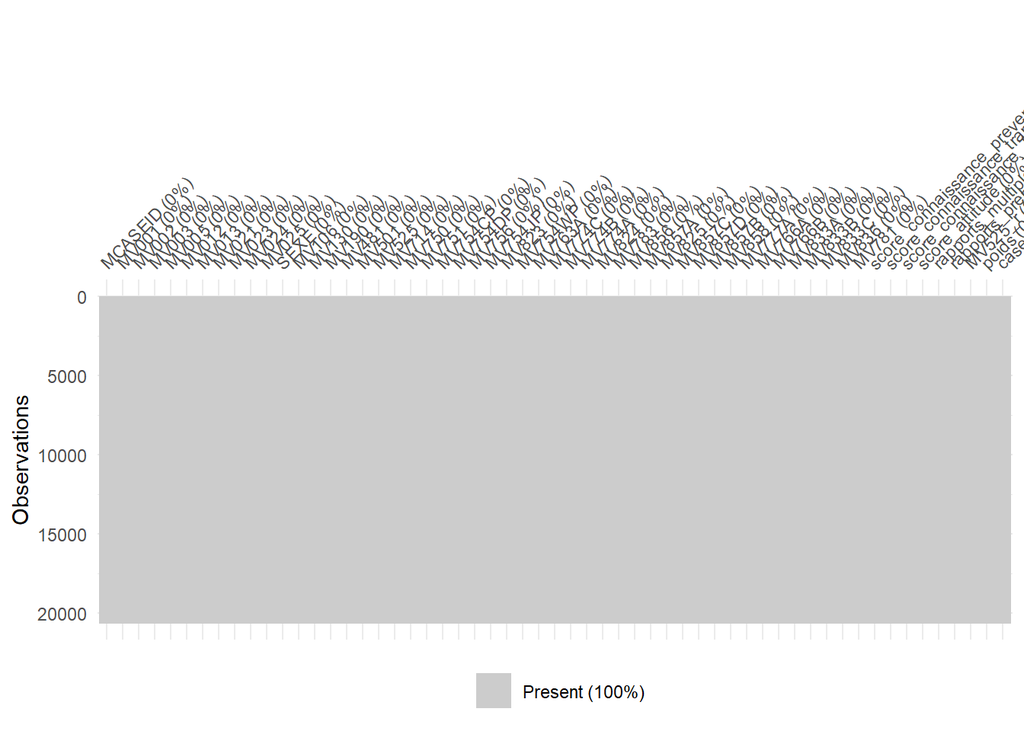

```r
# Visualisation des valeurs manquantes
library(naniar)

vis_miss(basefr,warn_large_data = FALSE)
```

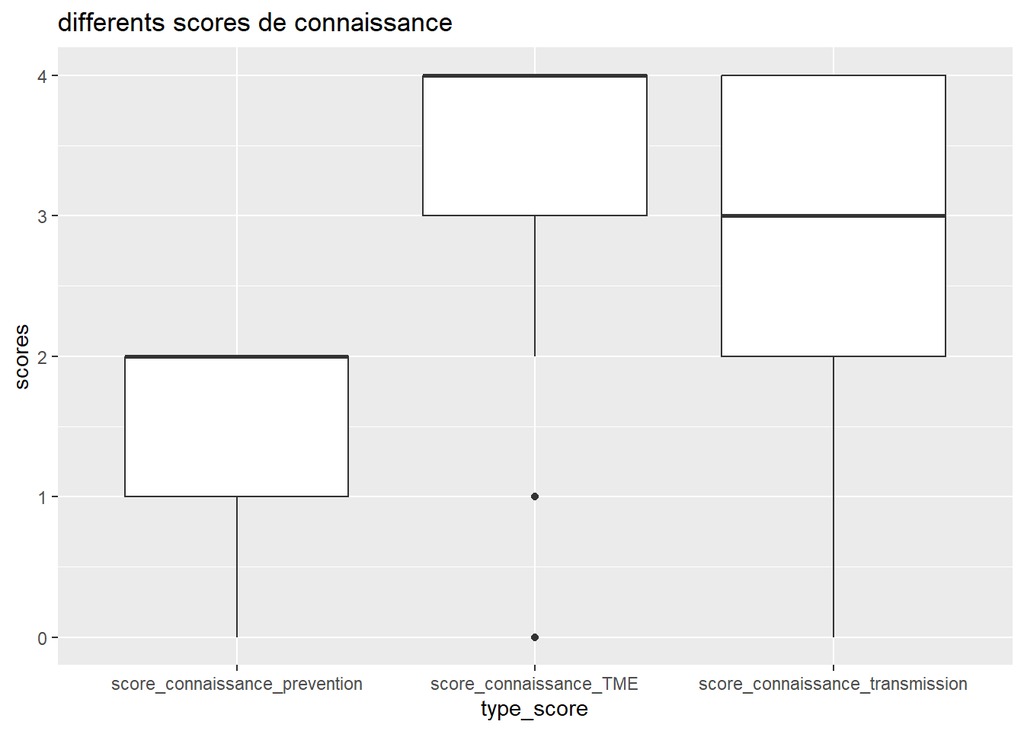

```r
# Analyse descriptive des variables d'interets----

## description des differents scores
data_uni <-  basefr %>%
  pivot_longer( cols =  c(score_connaissance_prevention,score_connaissance_transmission,score_connaissance_TME), names_to = "type_score", values_to =  "scores")#reorganisationdu dataframe

## distribution du score de connaissance

ggplot(data_uni)+
  aes( x = type_score , y = scores)+
  geom_boxplot()+
  ggtitle( "differents scores de connaissance")
```

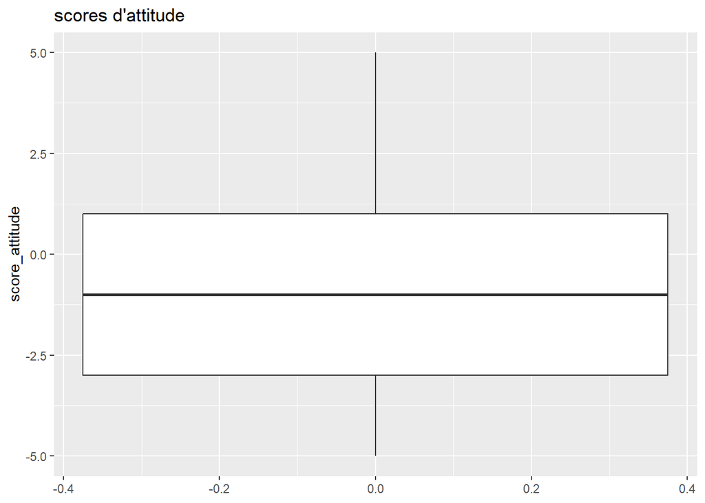

```r
## distribution du score d'attitude
ggplot(basefr)+
  aes( y = score_attitude)+
  geom_boxplot()+
  ggtitle("scores d'attitude")
```

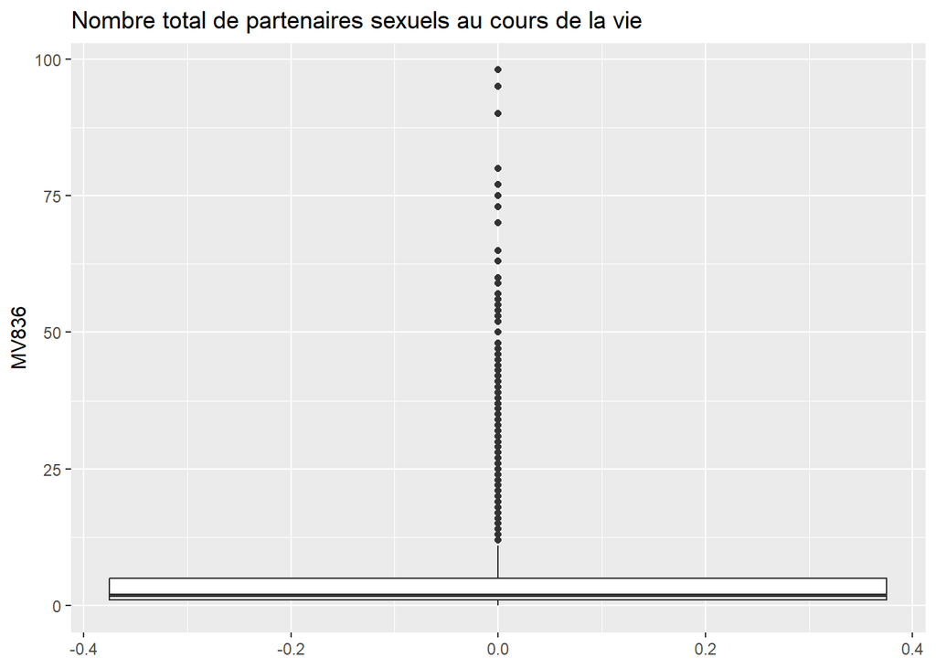

```r
## Distribution du nombre de partenaire au cours de la vie
ggplot(basefr)+
  aes( y = MV836)+
  geom_boxplot()+
  ggtitle("Nombre total de partenaires sexuels au cours de la vie")
```

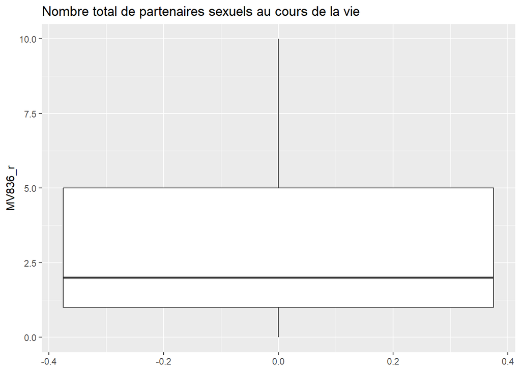

```r
## Fixons a 10 le nombre de partenaires total au cours de la vie pour tout ceux ayant declaree avoir eu plus de 10 partenaires

basefr <- basefr %>%
  mutate(MV836_r = ifelse( MV836 > 10, 10, MV836))

ggplot(basefr)+
  aes( y = MV836_r)+
  geom_boxplot()+
  ggtitle("Nombre total de partenaires sexuels au cours de la vie")
```

```r
labelled::var_label(basefr) <-list(  MV836_r = "Nombre total de partenaire au cours de la vie")
```

```r
## Description des pratiques sexuelles

basefr %>%
  tbl_summary( include = c("rapports_multiples","rapports_prenuptiaux","MV525_r", "MV836_r","MV833A",
                           "MV833B", "MV833C")) %>%
  bold_labels() %>%

  italicize_labels()
```

| **Caractéristique** | **N = 20 680**<sup>1</sup> |
| --- | --- |
| partenaires sexuelles au cours des 12 derniers mois |  |
| Aucun partenaire au cours des 12 derniers mois | 5 413 (26%) |
| Ont eu Un partenaire au cours des 12 derniers mois | 13 100 (63%) |
| Ont eu 2 partenaires au cours des 12 derniers mois,sans chevauchement | 3 (<0,1%) |
| Ont eu 2 partenaires se chevauchant au cours des 12 derniers mois | 1 729 (8,4%) |
| Ont eu plus de 2 partenaires se chevauchant au cours des 12 derniers mois | 331 (1,6%) |
| Ont eu plus de 2 partenaires au cours des 12 derniers mois,sans chevauchement | 104 (0,5%) |
| rapports_prenuptiaux |  |
| Oui | 12 870 (62%) |
| Non | 7 810 (38%) |
| Rapports sexuels precoces (< 16 ans) |  |
| Non | 14 997 (73%) |
| Oui | 5 683 (27%) |
| Nombre total de partenaire au cours de la vie | 2,0 (1,0 – 5,0) |
| préservatif toujours utilise lors des rapports sexuels avec le plus récent partenaire |  |
| Oui | 2 060 (10,0%) |
| Non | 1 137 (5,5%) |
| Non-Applicable | 17 483 (85%) |
| préservatif toujours utilise lors des rapports sexuels avec le deuxième partenaire le plus recent |  |
| Non | 259 (1,3%) |
| Oui | 934 (4,5%) |
| Non-Applicable | 19 487 (94%) |
| préservatif toujours utilise lors des rapports sexuels avec le troisieme partenaire le plus recent |  |
| Non | 52 (0,3%) |
| Oui | 202 (1,0%) |
| Non-Applicable | 20 426 (99%) |

<sup>1</sup> n (%); Médiane (Q1 – Q3)

```r
## Description des caracteristiques socio demographiques
basefr%>%
  tbl_summary( include = c("MV012","SEXE", "MV024","MV025","MV106",
                           "MV130","MV190","MV481","MV714", "MV501")) %>%
  bold_labels() %>%

  italicize_labels()
```

| **Caractéristique** | **N = 20 680**<sup>1</sup> |
| --- | --- |
| age | 28 (20 – 38) |
| sexe |  |
| Masculin | 6 636 (32%) |
| Feminin | 14 044 (68%) |
| Region |  |
| Adamawa | 1 381 (6,7%) |
| Centre (sans Yaoundé) | 2 371 (11%) |
| Douala | 1 825 (8,8%) |
| Est | 1 703 (8,2%) |
| Extrême-Nord | 2 096 (10%) |
| Littoral (sans Douala) | 1 383 (6,7%) |
| Nord | 2 097 (10%) |
| Nord-Ouest | 1 020 (4,9%) |
| Ouest | 2 075 (10%) |
| Sud | 2 236 (11%) |
| Sud-Ouest | 538 (2,6%) |
| Yaoundé | 1 955 (9,5%) |
| zone de residence |  |
| rural | 9 531 (46%) |
| Urbain | 11 149 (54%) |
| niveau d'education |  |
| Pas d'éducation | 3 148 (15%) |
| Primaire | 5 839 (28%) |
| Secondaire | 9 988 (48%) |
| Supérieur | 1 705 (8,2%) |
| Religion |  |
| Aucun | 437 (2,1%) |
| Animiste | 368 (1,8%) |
| Chretien | 15 231 (74%) |
| Musulman | 4 525 (22%) |
| Autre | 119 (0,6%) |
| index de richesse |  |
| pauvre | 6 661 (32%) |
| Milieu | 4 947 (24%) |
| riche | 9 072 (44%) |
| Couvert par l'assurance maladie |  |
| Non | 18 974 (92%) |
| Oui | 622 (3,0%) |
| Manquant | 1 084 (5,2%) |
| Travaille actuellement |  |
| Non | 6 617 (32%) |
| Oui | 14 063 (68%) |
| statut matrimonial |  |
| Divorcé | 262 (1,3%) |
| Jamais en union | 7 884 (38%) |
| Marié | 7 962 (39%) |
| Ne plus vivre ensemble/séparés | 957 (4,6%) |
| Veuf | 775 (3,7%) |
| Vivre avec partenaire | 2 840 (14%) |

<sup>1</sup> Médiane (Q1 – Q3); n (%)

```r
## Analyse Bivariee----

##definition de l'objet d'enquete dp

dp <- svydesign(ids = ~MV021, strata = ~MV023, weights =~poids, data= basefr)

## Caracteristiques sociodemographique entre cas et temoins
dp%>%
  tbl_svysummary( include = c("MV012","SEXE", "MV024","MV025","MV106", "MV130","MV190","MV481","MV714", "MV501"),
                  by = "case_control", statistic = list(all_categorical()~ "{n}({p}%)", all_continuous() ~ "{median} ({p25}, {p75})"),
                  percent = "row",
                  #digits =  all_categorical() ~ c(0,2)
  ) %>%
  add_overall( last = TRUE) %>%

  add_p()%>%

  add_stat_label()%>%

  separate_p_footnotes() %>%

  bold_labels() %>%

  italicize_labels() #%>%
```

[output not shown]

| **Caractéristique** | **Non Dépisté** N = 11 791 | **Dépisté** N = 8 961 | **Overall** N = 20 752 | **p-valeur** |
| --- | --- | --- | --- | --- |
| age, Médiane (Q1, Q3) | 27 (19, 39) | 29 (22, 37) | 28 (20, 38) | <0,001<sup>1</sup> |
| sexe, n(%) |  |  |  | <0,001<sup>2</sup> |
| Masculin | 4 037(60%) | 2 639(40%) | 6 676(100%) |  |
| Feminin | 7 754(55%) | 6 322(45%) | 14 077(100%) |  |
| Region, n(%) |  |  |  | <0,001<sup>2</sup> |
| Adamawa | 644(71%) | 259(29%) | 904(100%) |  |
| Centre (sans Yaoundé) | 1 306(58%) | 957(42%) | 2 263(100%) |  |
| Douala | 1 022(39%) | 1 571(61%) | 2 593(100%) |  |
| Est | 686(56%) | 532(44%) | 1 218(100%) |  |
| Extrême-Nord | 2 377(80%) | 601(20%) | 2 979(100%) |  |
| Littoral (sans Douala) | 439(54%) | 380(46%) | 819(100%) |  |
| Nord | 1 945(75%) | 657(25%) | 2 602(100%) |  |
| Nord-Ouest | 474(38%) | 760(62%) | 1 233(100%) |  |
| Ouest | 1 257(56%) | 991(44%) | 2 247(100%) |  |
| Sud | 622(55%) | 506(45%) | 1 129(100%) |  |
| Sud-Ouest | 188(42%) | 262(58%) | 450(100%) |  |
| Yaoundé | 829(36%) | 1 485(64%) | 2 314(100%) |  |
| zone de residence, n(%) |  |  |  | <0,001<sup>2</sup> |
| rural | 6 354(69%) | 2 902(31%) | 9 256(100%) |  |
| Urbain | 5 437(47%) | 6 059(53%) | 11 496(100%) |  |
| niveau d'education, n(%) |  |  |  | <0,001<sup>2</sup> |
| Pas d'éducation | 2 933(80%) | 755(20%) | 3 688(100%) |  |
| Primaire | 3 423(61%) | 2 174(39%) | 5 597(100%) |  |
| Secondaire | 4 938(51%) | 4 730(49%) | 9 668(100%) |  |
| Supérieur | 497(28%) | 1 302(72%) | 1 799(100%) |  |
| Religion, n(%) |  |  |  | <0,001<sup>2</sup> |
| Aucun | 268(58%) | 193(42%) | 461(100%) |  |
| Animiste | 366(78%) | 105(22%) | 470(100%) |  |
| Chretien | 7 591(51%) | 7 168(49%) | 14 759(100%) |  |
| Musulman | 3 506(71%) | 1 443(29%) | 4 949(100%) |  |
| Autre | 60(54%) | 52(46%) | 113(100%) |  |
| index de richesse, n(%) |  |  |  | <0,001<sup>2</sup> |
| pauvre | 5 236(74%) | 1 849(26%) | 7 085(100%) |  |
| Milieu | 2 511(59%) | 1 719(41%) | 4 230(100%) |  |
| riche | 4 044(43%) | 5 393(57%) | 9 437(100%) |  |
| Couvert par l'assurance maladie, n(%) |  |  |  | <0,001<sup>2</sup> |
| Non | 10 918(57%) | 8 193(43%) | 19 111(100%) |  |
| Oui | 194(30%) | 452(70%) | 647(100%) |  |
| Manquant | 679(68%) | 316(32%) | 995(100%) |  |
| Travaille actuellement, n(%) |  |  |  | 0,6<sup>2</sup> |
| Non | 3 685(57%) | 2 756(43%) | 6 442(100%) |  |
| Oui | 8 106(57%) | 6 205(43%) | 14 310(100%) |  |
| statut matrimonial, n(%) |  |  |  | <0,001<sup>2</sup> |
| Divorcé | 167(67%) | 81(33%) | 248(100%) |  |
| Jamais en union | 4 586(60%) | 3 120(40%) | 7 706(100%) |  |
| Marié | 4 932(57%) | 3 660(43%) | 8 592(100%) |  |
| Ne plus vivre ensemble/séparés | 433(49%) | 452(51%) | 885(100%) |  |
| Veuf | 490(65%) | 262(35%) | 752(100%) |  |
| Vivre avec partenaire | 1 183(46%) | 1 386(54%) | 2 569(100%) |  |

<sup>1</sup> Design-based KruskalWallis test  
<sup>2</sup> Pearson’s X^2: Rao & Scott adjustment

```r
  #as_flex_table() #%>%
 #save_as_docx( path = "socio_demo.docx")

## Comparaison des connaissances entre cas et temoins
dp%>%
  tbl_svysummary( include = c("score_connaissance_prevention","MV754CP",
                              "MV754DP",
                              "score_connaissance_transmission","MV756","MV754JP",
                              "MV823","MV754WP",
                              "score_connaissance_TME","MV774C", "MV774B","MV774A",
                              "MV824"),
                  by = "case_control", statistic = list(all_categorical()~ "{n}({p}%)"),
                  type = c(score_connaissance_prevention,score_connaissance_transmission,
                           score_connaissance_TME) ~ "continuous",missing = "no",
                  percent = "row"
  ) %>%
  add_overall( last =TRUE) %>%

  add_p(test = list(all_continuous() ~ "svy.wilcox.test", all_categorical() ~ "svy.chisq.test"))%>%

  add_stat_label()%>%

  separate_p_footnotes() %>%

  bold_labels() %>%

  italicize_labels()# %>%
```

[output not shown]

| **Caractéristique** | **Non Dépisté** N = 11 791 | **Dépisté** N = 8 961 | **Overall** N = 20 752 | **p-valeur** |
| --- | --- | --- | --- | --- |
| Score de connaissance des moyens de prevention, Médiane (Q1 – Q3) | 2,00 (1,00 – 2,00) | 2,00 (2,00 – 2,00) | 2,00 (1,00 – 2,00) | <0,001<sup>1</sup> |
| utiliser le preservatif reduit le risque d'infection, n(%) |  |  |  | <0,001<sup>2</sup> |
| Je ne sais pas | 628(76%) | 199(24%) | 827(100%) |  |
| Non | 2 477(68%) | 1 188(32%) | 3 664(100%) |  |
| Oui | 8 687(53%) | 7 575(47%) | 16 261(100%) |  |
| avoir un partenaire sexuel reduit le risque, n(%) |  |  |  | <0,001<sup>2</sup> |
| Je ne sais pas | 553(77%) | 163(23%) | 717(100%) |  |
| Non | 1 739(70%) | 728(30%) | 2 467(100%) |  |
| Oui | 9 498(54%) | 8 070(46%) | 17 568(100%) |  |
| Score de connaissance des moyens de transmission, Médiane (Q1 – Q3) | 3,00 (2,00 – 4,00) | 3,00 (3,00 – 4,00) | 3,00 (2,00 – 4,00) | <0,001<sup>1</sup> |
| une personne physiquement bien portante peut avoir le VIH, n(%) |  |  |  | <0,001<sup>2</sup> |
| Ne sait pas | 436(78%) | 121(22%) | 557(100%) |  |
| Non | 2 016(74%) | 714(26%) | 2 730(100%) |  |
| Oui | 9 339(53%) | 8 126(47%) | 17 465(100%) |  |
| Transmission par partage de nourriture, n(%) |  |  |  | <0,001<sup>2</sup> |
| Je ne sais pas | 782(64%) | 437(36%) | 1 219(100%) |  |
| Non | 7 902(55%) | 6 498(45%) | 14 400(100%) |  |
| Oui | 3 107(61%) | 2 026(39%) | 5 133(100%) |  |
| transmission par des moyens surnaturels, n(%) |  |  |  | 0,6<sup>2</sup> |
| Je ne sais pas | 1 046(57%) | 775(43%) | 1 821(100%) |  |
| Non | 8 287(56%) | 6 390(44%) | 14 676(100%) |  |
| Oui | 2 459(58%) | 1 797(42%) | 4 255(100%) |  |
| Transmission par partage de nourriture, n(%) |  |  |  | <0,001<sup>2</sup> |
| Je ne sais pas | 580(71%) | 236(29%) | 817(100%) |  |
| Non | 9 357(55%) | 7 715(45%) | 17 072(100%) |  |
| Oui | 1 854(65%) | 1 010(35%) | 2 863(100%) |  |
| Score de connaissance sur la transmission mère-enfant, Médiane (Q1 – Q3) | 3,00 (2,00 – 4,00) | 4,00 (3,00 – 4,00) | 4,00 (3,00 – 4,00) | <0,001<sup>1</sup> |
| transmission au cours de l'allaitement, n(%) |  |  |  | <0,001<sup>2</sup> |
| Ne sait pas | 1 004(70%) | 433(30%) | 1 437(100%) |  |
| Non | 1 798(65%) | 972(35%) | 2 770(100%) |  |
| Oui | 8 989(54%) | 7 556(46%) | 16 545(100%) |  |
| transmission au cours de l'accouchement, n(%) |  |  |  | <0,001<sup>2</sup> |
| Ne sait pas | 995(71%) | 401(29%) | 1 396(100%) |  |
| Non | 1 994(67%) | 988(33%) | 2 981(100%) |  |
| Oui | 8 802(54%) | 7 573(46%) | 16 375(100%) |  |
| transmission au cours de la grossesse, n(%) |  |  |  | <0,001<sup>2</sup> |
| Ne sait pas | 917(74%) | 327(26%) | 1 244(100%) |  |
| Non | 2 878(63%) | 1 682(37%) | 4 560(100%) |  |
| Oui | 7 996(53%) | 6 952(47%) | 14 949(100%) |  |
| Existance des médicaments pour prevenir la TME pendant l'allaitement, n(%) |  |  |  | <0,001<sup>2</sup> |
| Je ne sais pas | 688(67%) | 345(33%) | 1 033(100%) |  |
| Non | 1 559(73%) | 575(27%) | 2 134(100%) |  |
| Oui | 7 873(51%) | 7 447(49%) | 15 320(100%) |  |
| Non-Applicable | 1 671(74%) | 594(26%) | 2 265(100%) |  |

<sup>1</sup> Design-based KruskalWallis test  
<sup>2</sup> Pearson’s X^2: Rao & Scott adjustment

```r
## Attitudes entre cas te temoins

dp%>%
  tbl_svysummary( include = c("score_attitude",
                              "MV857A",
                              "MV825", "MV857D", "MV777A","MV858"),
                  by = "case_control", statistic = list(all_categorical()~ "{n}({p}%)"),
                  type =  score_attitude ~ "continuous",missing = "no",
                  percent = "row"
  ) %>%
  add_overall( last =TRUE) %>%

  add_p(test = list(all_continuous() ~ "svy.wilcox.test", all_categorical() ~ "svy.chisq.test"))%>%

  add_stat_label()%>%

  separate_p_footnotes() %>%

  bold_labels() %>%

  italicize_labels() #%>%
```

| **Caractéristique** | **Non Dépisté** N = 11 791 | **Dépisté** N = 8 961 | **Overall** N = 20 752 | **p-valeur** |
| --- | --- | --- | --- | --- |
| Score sur des attitudes discriminatoires, Médiane (Q1 – Q3) | -1,00 (-3,00 – 1,00) | -1,00 (-3,00 – -1,00) | -1,00 (-3,00 – 1,00) | <0,001<sup>1</sup> |
| Les enfants séropositifs devraient être autorisés à assister au cours comme les autres , n(%) |  |  |  | <0,001<sup>2</sup> |
| Ne sait pas | 456(62%) | 276(38%) | 732(100%) |  |
| Oui | 7 704(52%) | 7 189(48%) | 14 892(100%) |  |
| Non | 3 631(71%) | 1 496(29%) | 5 128(100%) |  |
| Achat des légumes à un vendeur séropositif, n(%) |  |  |  | <0,001<sup>2</sup> |
| Je ne sais pas | 392(62%) | 242(38%) | 634(100%) |  |
| Oui | 6 199(49%) | 6 425(51%) | 12 624(100%) |  |
| Non | 5 200(69%) | 2 295(31%) | 7 494(100%) |  |
| Les personnes séropositives ou soupçonnées d'être séropositives perdent leur respect, n(%) |  |  |  | 0,5<sup>2</sup> |
| Ne sait pas | 542(58%) | 391(42%) | 933(100%) |  |
| Oui | 8 595(57%) | 6 615(43%) | 15 210(100%) |  |
| Non | 2 654(58%) | 1 955(42%) | 4 609(100%) |  |
| J'aurais honte si un membre de la famille avait le VIH, n(%) |  |  |  | <0,001<sup>2</sup> |
| Je ne sais pas | 319(66%) | 166(34%) | 485(100%) |  |
| Oui | 3 314(72%) | 1 282(28%) | 4 596(100%) |  |
| Non | 8 158(52%) | 7 514(48%) | 15 672(100%) |  |
| Peur d'entrer en contact avec la salive d'une personne ayant le VIH, n(%) |  |  |  | <0,001<sup>2</sup> |
| il dit qu'il a le VIH | 45(49%) | 46(51%) | 91(100%) |  |
| je ne sais pas | 513(59%) | 355(41%) | 867(100%) |  |
| Non | 4 139(53%) | 3 698(47%) | 7 836(100%) |  |
| Oui | 7 094(59%) | 4 863(41%) | 11 957(100%) |  |

<sup>1</sup> Design-based KruskalWallis test  
<sup>2</sup> Pearson’s X^2: Rao & Scott adjustment

```r
## Pratiques sexuelles entre cas et  temoins

dp%>%
  tbl_svysummary( include = c("MV833A","MV833B", "MV833C","rapports_multiples","rapports_prenuptiaux","MV525_r",
                              "MV836_r"),
                  by = "case_control", statistic = list(all_categorical()~ "{n}({p}%)"),
                  ,missing = "always",
                  percent = "row"
  ) %>%
  add_overall( last =TRUE) %>%

  add_p(test = list(all_continuous() ~ "svy.wilcox.test", all_categorical() ~ "svy.chisq.test"))%>%

  add_stat_label()%>%

  separate_p_footnotes() %>%

  bold_labels() %>%

  italicize_labels() #%>%
```

```
## The following warnings were returned during `separate_p_footnotes()`:
## ! For variable `rapports_multiples` (`case_control`) and "statistic" and
##   "p.value" statistics: L’approximation du Chi-2 est peut-être incorrecte
```

| **Caractéristique** | **Non Dépisté** N = 11 791 | **Dépisté** N = 8 961 | **Overall** N = 20 752 | **p-valeur** |
| --- | --- | --- | --- | --- |
| préservatif toujours utilise lors des rapports sexuels avec le plus récent partenaire, n(%) |  |  |  | <0,001<sup>1</sup> |
| Oui | 882(44%) | 1 102(56%) | 1 983(100%) |  |
| Non | 423(40%) | 638(60%) | 1 062(100%) |  |
| Non-Applicable | 10 486(59%) | 7 221(41%) | 17 707(100%) |  |
| Manquant | 0 | 0 | 0 |  |
| préservatif toujours utilise lors des rapports sexuels avec le deuxième partenaire le plus recent , n(%) |  |  |  | <0,001<sup>1</sup> |
| Non | 110(45%) | 137(55%) | 247(100%) |  |
| Oui | 323(37%) | 557(63%) | 880(100%) |  |
| Non-Applicable | 11 357(58%) | 8 267(42%) | 19 625(100%) |  |
| Manquant | 0 | 0 | 0 |  |
| préservatif toujours utilise lors des rapports sexuels avec le troisieme partenaire le plus recent , n(%) |  |  |  | <0,001<sup>1</sup> |
| Non | 23(43%) | 31(57%) | 54(100%) |  |
| Oui | 71(40%) | 105(60%) | 176(100%) |  |
| Non-Applicable | 11 697(57%) | 8 825(43%) | 20 523(100%) |  |
| Manquant | 0 | 0 | 0 |  |
| partenaires sexuelles au cours des 12 derniers mois, n(%) |  |  |  | <0,001<sup>1</sup> |
| Aucun partenaire au cours des 12 derniers mois | 3 967(73%) | 1 477(27%) | 5 443(100%) |  |
| Ont eu Un partenaire au cours des 12 derniers mois | 6 846(52%) | 6 370(48%) | 13 216(100%) |  |
| Ont eu 2 partenaires au cours des 12 derniers mois,sans chevauchement | 3(61%) | 2(39%) | 5(100%) |  |
| Ont eu 2 partenaires se chevauchant au cours des 12 derniers mois | 787(47%) | 890(53%) | 1 677(100%) |  |
| Ont eu plus de 2 partenaires se chevauchant au cours des 12 derniers mois | 146(46%) | 170(54%) | 317(100%) |  |
| Ont eu plus de 2 partenaires au cours des 12 derniers mois,sans chevauchement | 42(44%) | 53(56%) | 94(100%) |  |
| Manquant | 0 | 0 | 0 |  |
| rapports_prenuptiaux, n(%) |  |  |  | <0,001<sup>1</sup> |
| Oui | 5 955(48%) | 6 441(52%) | 12 395(100%) |  |
| Non | 5 836(70%) | 2 521(30%) | 8 357(100%) |  |
| Manquant | 0 | 0 | 0 |  |
| Rapports sexuels precoces (< 16 ans), n(%) |  |  |  | 0,003<sup>1</sup> |
| Non | 8 598(56%) | 6 740(44%) | 15 338(100%) |  |
| Oui | 3 193(59%) | 2 221(41%) | 5 414(100%) |  |
| Manquant | 0 | 0 | 0 |  |
| Nombre total de partenaire au cours de la vie, Médiane (Q1 – Q3) | 2,0 (1,0 – 4,0) | 3,0 (1,0 – 6,0) | 2,0 (1,0 – 5,0) | <0,001<sup>2</sup> |
| Manquant | 0 | 0 | 0 |  |

<sup>1</sup> Pearson’s X^2: Rao & Scott adjustment  
<sup>2</sup> Design-based KruskalWallis test

```r
## Recodage des variables pour la regression
basefr$MV024 <- basefr$MV024 %>%
  fct_recode(
    "Regions septentrionales" = "Adamawa",
    "Regions francophones" = "Centre (sans Yaoundé)",
    "Métropoles" = "Douala",
    "Regions francophones" = "Est",
    "Regions septentrionales" = "Extrême-Nord",
    "Regions francophones" = "Littoral (sans Douala)",
    "Regions septentrionales" = "Nord",
    "Regions anglophones" = "Nord-Ouest",
    "Regions francophones" = "Ouest",
    "Regions francophones" = "Sud",
    "Regions anglophones" = "Sud-Ouest",
    "Métropoles" = "Yaoundé"
  )
## Réordonnancement de basefr$MV501
basefr$MV501 <- basefr$MV501 %>%
  fct_relevel(
    "Jamais en union", "Divorcé", "Marié", "Ne plus vivre ensemble/séparés",
    "Veuf", "Vivre avec partenaire"
  )
## Réordonnancement de basefr$MV024
basefr$MV024 <- basefr$MV024 %>%
  fct_relevel(
    "Regions francophones", "régions septentrionales", "Regions anglophones",
    "Métropoles"
  )
labelled::var_label(basefr) <-list(  MV024 = "Region",
                                     MV501 = "statut matrimonial")


labelled::var_label(basefr) <-list(MV833A =" préservatif toujours utilise lors des rapports sexuels avec le plus récent partenaire",
                                    MV833B=" préservatif toujours utilise lors des rapports sexuels avec le deuxième partenaire le plus recent
", MV833C=" préservatif toujours utilise lors des rapports sexuels avec le troisieme  partenaire le plus recent
", MV836 ="Nombre total de partenaires sexuels au cours de la vie", MV481 = "Couvert par l'assurance maladie")





####definition de l'objet d'enquete dp2
dp2 <- svydesign(ids = ~MV021, strata = ~MV023, weights =~poids, data= basefr)
```

```r
## Regression univariee----

univ_tab <- dp2 %>%
  tbl_uvregression(
    method = svyglm,
    y = case_control,
    method.args = list(family = quasibinomial()),
    include = c(MV012,SEXE, MV024,MV025,MV106,MV130,MV190,MV481, MV501,MV525_r,rapports_multiples,rapports_prenuptiaux,MV836_r,MV833A, MV833B, MV833C,score_connaissance_prevention,score_connaissance_prevention,score_connaissance_TME,score_attitude,score_connaissance_transmission),
    exponentiate = TRUE
  )

## Regression multivariée----

model1 <-  svyglm(case_control~MV012+SEXE+MV024+MV025+MV106+MV130+MV190+MV481+MV501+MV525_r+rapports_multiples+rapports_prenuptiaux+MV836_r+MV833A+MV833B+MV833C+score_connaissance_prevention+score_connaissance_prevention+score_connaissance_TME+score_attitude+score_connaissance_transmission, family = "quasibinomial", design = dp2 )

## Recherche du modele le plus parcimonieux en minimisant l'AIC

model2 <-  step(model1)  ## selection pas a pas descendante a partie du model1
```

```
## Start:  AIC=24236.58
## case_control ~ MV012 + SEXE + MV024 + MV025 + MV106 + MV130 +
##     MV190 + MV481 + MV501 + MV525_r + rapports_multiples + rapports_prenuptiaux +
##     MV836_r + MV833A + MV833B + MV833C + score_connaissance_prevention +
##     score_connaissance_prevention + score_connaissance_TME +
##     score_attitude + score_connaissance_transmission
##
##                                   Df Deviance   AIC
## - MV130                            4    24110 24233
## - MV833A                           2    24106 24234
## - MV833C                           2    24106 24234
## <none>                                  24105 24237
## - MV025                            1    24108 24237
## - MV525_r                          1    24114 24243
## - MV833B                           2    24117 24245
## - MV481                            2    24122 24249
## - MV012                            1    24121 24251
## - MV836_r                          1    24122 24251
## - score_connaissance_transmission  1    24127 24256
## - score_attitude                   1    24145 24275
## - score_connaissance_prevention    1    24153 24282
## - MV501                            5    24163 24284
## - rapports_prenuptiaux             1    24159 24289
## - MV190                            2    24173 24300
## - SEXE                             1    24187 24316
## - score_connaissance_TME           1    24200 24329
## - MV106                            3    24265 24390
## - rapports_multiples               5    24275 24396
## - MV024                            3    24421 24545
##
## Step:  AIC=24227.89
## case_control ~ MV012 + SEXE + MV024 + MV025 + MV106 + MV190 +
##     MV481 + MV501 + MV525_r + rapports_multiples + rapports_prenuptiaux +
##     MV836_r + MV833A + MV833B + MV833C + score_connaissance_prevention +
##     score_connaissance_TME + score_attitude + score_connaissance_transmission
##
##                                   Df Deviance   AIC
## - MV833A                           2    24111 24225
## - MV833C                           2    24111 24225
## <none>                                  24110 24228
```

[output cut: 55 more lines]

```
## - MV833B                           2    24124 24228
## - MV481                            2    24128 24232
## - MV012                            1    24128 24234
## - MV836_r                          1    24130 24236
## - score_connaissance_transmission  1    24133 24239
## - score_attitude                   1    24153 24259
## - score_connaissance_prevention    1    24162 24268
## - rapports_prenuptiaux             1    24166 24272
## - MV501                            5    24175 24273
## - MV190                            2    24180 24284
## - SEXE                             1    24200 24306
## - score_connaissance_TME           1    24206 24313
## - MV106                            3    24282 24384
## - rapports_multiples               5    24301 24399
## - MV024                            3    24456 24557
```

```r
## Verification de l'absence de multicolinearite

library(car)
vif(model2)
```

```
##                                     GVIF Df GVIF^(1/(2*Df))
## MV012                           2.704477  1        1.644529
## SEXE                            1.447394  1        1.203077
## MV024                           3.402277  3        1.226389
## MV025                           2.120613  1        1.456233
## MV106                           2.309109  3        1.149672
## MV190                           2.379704  2        1.242026
## MV481                           1.817420  2        1.161084
## MV501                           5.654861  5        1.189165
## MV525_r                         1.309677  1        1.144411
## rapports_multiples              8.200335  5        1.234193
## rapports_prenuptiaux            1.610504  1        1.269056
## MV836_r                         1.934037  1        1.390696
## MV833B                          3.060907  2        1.322704
## score_connaissance_prevention   1.303897  1        1.141883
## score_connaissance_TME          1.331349  1        1.153841
## score_attitude                  1.260483  1        1.122713
## score_connaissance_transmission 1.355907  1        1.164434
```

```r
mv_tab <- model2 %>%
  tbl_regression(exponentiate = TRUE)

## Combinaison de la table regression univariée et multivariée

tbl_merge(tbls = list(univ_tab, mv_tab),
          tab_spanner = c("**Analyse Brute**", "**Analyse Ajustée**")) %>%
  bold_labels() %>%
  italicize_labels() #%>%
```

| **Caractéristique** | **Analyse Brute** **N** | **Analyse Brute** **OR**<sup>1</sup> | **Analyse Brute** **95% IC**<sup>1</sup> | **Analyse Brute** **p-valeur** | **Analyse Ajustée** **OR**<sup>1</sup> | **Analyse Ajustée** **95% IC**<sup>1</sup> | **Analyse Ajustée** **p-valeur** |
| --- | --- | --- | --- | --- | --- | --- | --- |
| age | 20 752 | 1,00 | 1,00 – 1,01 | 0,005 | 0,99 | 0,99 – 1,00 | <0,001 |
| sexe | 20 752 |  |  |  |  |  |  |
| Masculin |  | — | — |  | — | — |  |
| Feminin |  | 1,25 | 1,15 – 1,35 | <0,001 | 1,46 | 1,32 – 1,61 | <0,001 |
| Region | 20 752 |  |  |  |  |  |  |
| Regions francophones |  | — | — |  | — | — |  |
| Regions anglophones |  | 1,98 | 1,71 – 2,29 | <0,001 | 2,15 | 1,84 – 2,52 | <0,001 |
| Métropoles |  | 2,11 | 1,87 – 2,39 | <0,001 | 1,51 | 1,30 – 1,76 | <0,001 |
| Regions septentrionales |  | 0,39 | 0,34 – 0,45 | <0,001 | 0,71 | 0,60 – 0,83 | <0,001 |
| zone de residence | 20 752 |  |  |  |  |  |  |
| rural |  | — | — |  | — | — |  |
| Urbain |  | 2,44 | 2,17 – 2,74 | <0,001 | 1,08 | 0,94 – 1,24 | 0,3 |
| niveau d'education | 20 752 |  |  |  |  |  |  |
| Pas d'éducation |  | — | — |  | — | — |  |
| Primaire |  | 2,47 | 2,12 – 2,87 | <0,001 | 1,49 | 1,27 – 1,75 | <0,001 |
| Secondaire |  | 3,72 | 3,21 – 4,32 | <0,001 | 1,69 | 1,44 – 1,98 | <0,001 |
| Supérieur |  | 10,2 | 8,43 – 12,3 | <0,001 | 2,98 | 2,42 – 3,66 | <0,001 |
| Religion | 20 752 |  |  |  |  |  |  |
| Aucun |  | — | — |  |  |  |  |
| Animiste |  | 0,40 | 0,27 – 0,57 | <0,001 |  |  |  |
| Chretien |  | 1,31 | 1,03 – 1,67 | 0,027 |  |  |  |
| Musulman |  | 0,57 | 0,43 – 0,76 | <0,001 |  |  |  |
| Autre |  | 1,20 | 0,76 – 1,89 | 0,4 |  |  |  |
| index de richesse | 20 752 |  |  |  |  |  |  |
| pauvre |  | — | — |  | — | — |  |
| Milieu |  | 1,94 | 1,71 – 2,20 | <0,001 | 1,31 | 1,16 – 1,48 | <0,001 |
| riche |  | 3,78 | 3,36 – 4,25 | <0,001 | 1,59 | 1,39 – 1,82 | <0,001 |
| Couvert par l'assurance maladie | 20 752 |  |  |  |  |  |  |
| Non |  | — | — |  | — | — |  |
| Oui |  | 3,10 | 2,58 – 3,73 | <0,001 | 1,43 | 1,17 – 1,75 | <0,001 |
| Manquant |  | 0,62 | 0,53 – 0,73 | <0,001 | 0,90 | 0,73 – 1,10 | 0,3 |
| statut matrimonial | 20 752 |  |  |  |  |  |  |
| Jamais en union |  | — | — |  | — | — |  |
| Divorcé |  | 0,71 | 0,51 – 1,0 | 0,047 | 1,43 | 1,02 – 2,02 | 0,040 |
| Marié |  | 1,09 | 0,99 – 1,20 | 0,069 | 1,44 | 1,27 – 1,62 | <0,001 |
| Ne plus vivre ensemble/séparés |  | 1,54 | 1,32 – 1,79 | <0,001 | 1,50 | 1,23 – 1,82 | <0,001 |
| Veuf |  | 0,79 | 0,65 – 0,95 | 0,014 | 1,69 | 1,33 – 2,15 | <0,001 |
| Vivre avec partenaire |  | 1,72 | 1,53 – 1,94 | <0,001 | 1,40 | 1,24 – 1,58 | <0,001 |
| Rapports sexuels precoces (< 16 ans) | 20 752 |  |  |  |  |  |  |
| Non |  | — | — |  | — | — |  |
| Oui |  | 0,89 | 0,82 – 0,96 | 0,003 | 0,89 | 0,82 – 0,97 | 0,008 |
| partenaires sexuelles au cours des 12 derniers mois | 20 752 |  |  |  |  |  |  |
| Aucun partenaire au cours des 12 derniers mois |  | — | — |  | — | — |  |
| Ont eu Un partenaire au cours des 12 derniers mois |  | 2,50 | 2,27 – 2,76 | <0,001 | 1,96 | 1,73 – 2,22 | <0,001 |
| Ont eu 2 partenaires au cours des 12 derniers mois,sans chevauchement |  | 1,70 | 0,12 – 23,5 | 0,7 | 2,08 | 0,11 – 40,9 | 0,6 |
| Ont eu 2 partenaires se chevauchant au cours des 12 derniers mois |  | 3,04 | 2,61 – 3,54 | <0,001 | 1,98 | 1,58 – 2,48 | <0,001 |
| Ont eu plus de 2 partenaires se chevauchant au cours des 12 derniers mois |  | 3,12 | 2,39 – 4,07 | <0,001 | 2,36 | 1,73 – 3,22 | <0,001 |
| Ont eu plus de 2 partenaires au cours des 12 derniers mois,sans chevauchement |  | 3,38 | 2,08 – 5,47 | <0,001 | 1,94 | 1,16 – 3,26 | 0,012 |
| rapports_prenuptiaux | 20 752 |  |  |  |  |  |  |
| Oui |  | — | — |  | — | — |  |
| Non |  | 0,40 | 0,37 – 0,44 | <0,001 | 0,74 | 0,68 – 0,82 | <0,001 |
| Nombre total de partenaire au cours de la vie | 20 752 | 1,10 | 1,09 – 1,12 | <0,001 | 1,03 | 1,01 – 1,04 | <0,001 |
| préservatif toujours utilise lors des rapports sexuels avec le plus récent partenaire | 20 752 |  |  |  |  |  |  |
| Oui |  | — | — |  |  |  |  |
| Non |  | 1,21 | 1,02 – 1,43 | 0,029 |  |  |  |
| Non-Applicable |  | 0,55 | 0,49 – 0,62 | <0,001 |  |  |  |
| préservatif toujours utilise lors des rapports sexuels avec le deuxième partenaire le plus recent | 20 752 |  |  |  |  |  |  |
| Non |  | — | — |  | — | — |  |
| Oui |  | 1,39 | 1,02 – 1,90 | 0,039 | 1,46 | 1,05 – 2,04 | 0,027 |
| Non-Applicable |  | 0,59 | 0,44 – 0,79 | <0,001 | 1,06 | 0,73 – 1,54 | 0,8 |
| préservatif toujours utilise lors des rapports sexuels avec le troisieme partenaire le plus recent | 20 752 |  |  |  |  |  |  |
| Non |  | — | — |  |  |  |  |
| Oui |  | 1,10 | 0,55 – 2,20 | 0,8 |  |  |  |
| Non-Applicable |  | 0,56 | 0,29 – 1,08 | 0,082 |  |  |  |
| Score de connaissance des moyens de prevention | 20 752 | 1,69 | 1,58 – 1,81 | <0,001 | 1,21 | 1,13 – 1,30 | <0,001 |
| Score de connaissance sur la transmission mère-enfant | 20 752 | 1,31 | 1,27 – 1,36 | <0,001 | 1,13 | 1,10 – 1,17 | <0,001 |
| Score sur des attitudes discriminatoires | 20 752 | 0,85 | 0,83 – 0,86 | <0,001 | 0,95 | 0,93 – 0,97 | <0,001 |
| Score de connaissance des moyens de transmission | 20 752 | 1,28 | 1,22 – 1,33 | <0,001 | 1,08 | 1,03 – 1,13 | <0,001 |

<sup>1</sup> OR = rapport de cotes, IC = intervalle de confiance

```r
  #as_flex_table() #%>%
 # save_as_docx( path = "regression.docx")
```

## 3 Resultats

Les résultats montrent qu’un meilleur niveau de connaissance des moyens de prévention (OR ajusté = 1,21, IC 95 % : 1,13 – 1,30), niveau de connaissance des moyens de transmission (OR ajusté = 1,08, IC 95 % : 1,03 – 1,13) et de la transmission mère-enfant (OR ajusté = 1,13, IC 95 % : 1,10 – 1,17) est associé à une probabilité accrue de se faire dépister. Les attitudes discriminatoires (OR ajusté = 0,95, IC 95 % : 0,93 – 0,97) réduisent l’accès au dépistage. Par ailleurs, des pratiques sexuelles à risque, telles que les rapports précoces (OR ajusté = 0,89, IC 95 % : 0,82 – 0,97) et un plus grand nombre de partenaires (OR ajusté = 1,94, IC 95 % : 1,16 – 3,26), influencent également l’accès au dépistage. L’utilisation du préservatif avec le deuxième partenaire montre une association positive (OR ajusté = 1,46, IC 95 % : 1,05 – 2,04).

```r
library(pROC)
```

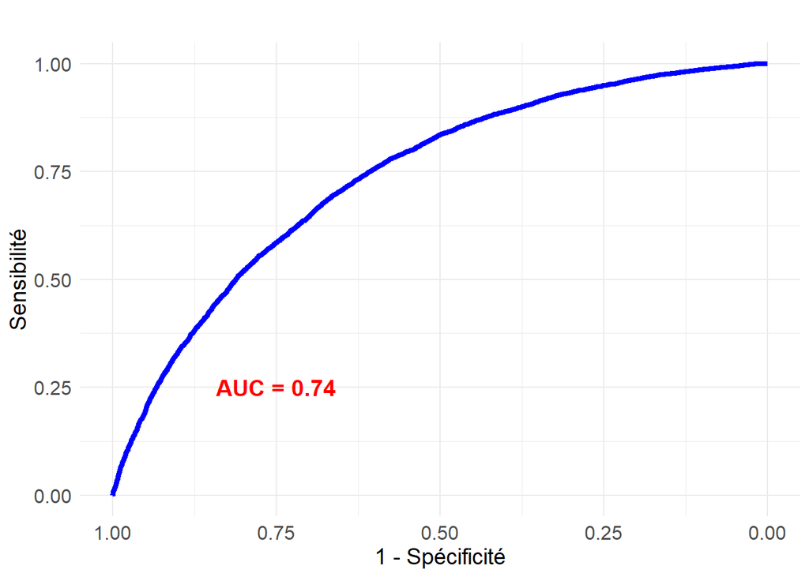

```r
# Prédictions de probabilités
prob_predictions <- predict.glm(model2, type = "response")

# Tracer la courbe ROC
roc_curve <- roc(dp2$variables$case_control, prob_predictions)
# Calculer l'AUC
auc_value <- auc(roc_curve)

# Tracer la courbe ROC avec ggplot2
ggroc(roc_curve, color = "blue", size = 1.5) +
  ggtitle("") +
  xlab("1 - Spécificité") +
  ylab("Sensibilité") +
  theme_minimal() +
  theme(
    plot.title = element_text(hjust = 0.5, size = 16),
    axis.title = element_text(size = 14),
    axis.text = element_text(size = 12)
  ) +
  annotate("text", x = 0.75, y = 0.25, label = paste("AUC =", round(auc_value, 2)),
           color = "red", size = 5, fontface = "bold")
```